# Semesterprüfung *Einführung Linguistik*

Südwest Jiaotong Universität, Wintersemester 2022/23

Aufgaben

Prüfer:in

Dr. Daniel Jach

Prüfungsdatum

21. Dezember 2022

[output not shown]

[figure not shown]

# Grundlagen

**Übungsaufgabe 1** Auf einer Studentenparty diskutieren Sie mit einem Biologie-Studenten über das Studium. Er behauptet, auch Tiere besäßen eine Sprache. Sie sind anderer Meinung. **Nennen und erläutern Sie** dem Biologie-Studierenden drei Eigenschaften, die menschliche Sprache von tierischen Kommunikationssystemen unterscheidet. (50-100 Wörter, 6 Punkte)

# Semiotik

**Übungsaufgabe 2** Sie studieren Sprachwissenschaft an einer deutschen Universität. Im Kurs werden verschiedene Arten sprachlicher Zeichen diskutiert. Ein Studierender behauptet, chinesische Schriftzeichen (汉字) seien Beispiele für Symbole. Ein anderer argumentiert, chinesische Schriftzeichen seien besser als Ikone einzuordnen. **Nehmen Sie begründet Stellung** in dieser Diskussion. **Veranschaulichen Sie** Ihre Argumente anhand von Beispielen. (50-100 Wörter, 6 Punkte)

# Semantik

**Übungsaufgabe 3** Auf einer Studentenparty diskutieren Sie mit einem Studenten der Literaturwissenschaft. Er behauptet, Metaphern seien eine Besonderheit von schöner Literatur (z.B. Gedichte, Romane) und nur dort zu finden. Als Beispiel zitiert er mit bebender Stimme aus Goethes Gedicht *Willkomm und Abschied* (1789):

Es schlug mein Herz, geschwind zu Pferde!  
Es war getan fast eh gedacht.  
Der Abend wiegte schon die Erde,  
Und an den Bergen hing die Nacht;  
Schon stand im Nebelkleid die Eiche,  
Ein aufgetürmter Riese, da,  
Wo Finsternis aus dem Gesträuche  
Mit hundert schwarzen Augen sah.

我的心在跳，赶快上马！  
霎时间立即奔上征途。  
黄昏已把大地摇入睡乡，  
群山笼罩着一片夜幕，  
槲树已披上云雾的衣裳，  
像屹立着的巨人一样，  
幽暗从那边的茂林之中  
睁着无数黑眼睛张望。

(Übersetzer: Qian Chunqi)

Sie sind anderer Meinung. **Erwidern Sie** aus sprachwissenschaftlicher Sicht. **Geben Sie** eine allgemeingültige Definition des Begriffs Metapher. **Erläutern Sie**, inwiefern nach dieser Definition das Wort *Nebelkleid* im Gedicht als Metapher zu verstehen ist. **Geben und erläutern Sie** ein allgemeinsprachliches Beispiel für eine Metapher. (100-200 Wörter, 12 Punkte)

# Pragmatik

**Übungsaufgabe 4** Strukturalismus und Pragmatik unterscheiden sich grundlegend in ihrem Sprachverständnis (d.h. in ihrem Verständnis davon, was Sprache ist). **Erläutern Sie**, wie sich die Pragmatik in ihrem allgemeinen Sprachverständnis vom Strukturalismus unterscheidet. **Erläutern Sie** anschließend, wie sich dieses unterschiedliche Verständnis in den folgenden unterschiedlichen Zeichenmodellen zeigt. (100-200 Wörter, 12 Punkte)

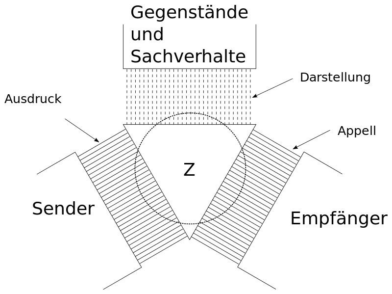

Pragmatisches Zeichenmodell von Karl Bühler

[figure not shown]

Strukturalistisches Zeichenmodell von Ferdinand de Saussure

# Textlinguistik

**Übungsaufgabe 5** Lesen Sie folgenden Auszug aus einem Brief eines Schizophrenie-Patienten (精神分裂症患者) an seine Mutter. **Diskutieren Sie**, ob dieser Auszug aus textlinguistischer Sicht als Text einzuordnen ist. Was spricht dafür, was dagegen? **Nehmen Sie dabei Bezug** auf verschiedene Textualitätsmerkmale inklusive Textsorten. (100-200 Wörter, 12 Punkte)

Liebe Mama!

Heute geht es mir besser als gestern. Eigentlich habe ich keine Lust zu schreiben. Ich schreibe auf Papier. Der Stift, den ich dazu benütze, ist von einer Fabrik, die *Perry und Co.* heißt. Die Fabrik ist in England. Ich nehme das an. Hinter dem Namen *Perry und Co.* ist die Stadt London eingeritzt; der Name, nicht die Stadt. Die Stadt London liegt in England. Ich weiß das aus der Schule. Da habe ich immer gern Geographie gehabt. Mein letzter Lehrer in der Schule war Professor August A. Das ist ein Mann mit schwarzen Augen. Ich habe die schwarzen Augen auch gern. Es gibt noch blaue und graue Augen, auch noch andere. Ich habe schon gehört, dass die Schlangen grüne Augen haben.

[…]

Beste Grüße

Dein Sohn

# Phonetik und Phonologie

**Übungsaufgabe 6** Das Chinesische hat vier (oder auch mehr) Töne. **Erläutern Sie** anhand geeigneter Beispiele in Pinyin mit Übersetzung, ob die chinesischen Töne allgemein besser als Phone oder als Phoneme einzuordnen sind. **Markieren Sie** die Töne mit entsprechenden diakritischen Zeichen über dem Vokal (z.B. ā á ǎ à). (50-100 Wörter, 6 Punkte)

# Morphologie

**Übungsaufgabe 7** Lesen Sie folgenden Auszug aus dem Märchen Schneewittchen. **Bestimmen Sie** die Wortart der markierten Wörter. Folgende Wortarten sind möglich: Verb, Nomen, Adjektiv, Pronomen, Artikel, Adverb, Präposition, Konjunktion und Partikel. (12 Wortarten, 12 Punkte)

Es war einmal mitten im Winter, und **die** Schneeflocken **fielen** wie Federn vom Himmel **herab**. Da saß eine Königin **an** einem Fenster, **das** einen Rahmen **von** schwarzem Ebenholz hatte, und nähte. Wie sie so nähte und nach dem Schnee aufblickte, stach **sie** sich mit der Nadel in den Finger, **und** es fielen drei Tropfen Blut in den Schnee. Und weil das Rote im weißen Schnee **so** schön aussah, dachte sie bei sich: Hätt’ ich ein Kind, so weiß wie Schnee, so rot wie Blut und so schwarz wie das Holz an dem Rahmen! **Bald** bekam sie **ein** Töchterlein, das war so weiß wie Schnee, so rot wie Blut und so schwarzhaarig wie Ebenholz und wurde **darum** Schneewittchen genannt.

# Syntax

**Übungsaufgabe 8** Schreiben Sie die folgenden zwei Sätze auf Ihr Antwortblatt. **Fertigen Sie eine komplette syntaktische Analyse** in Form einer Baumstruktur an. **Notieren Sie** Wortarten und Phrasenarten in der Baumstruktur, Satzgliedgrenzen mit eckigen Klammern im Satz und syntaktische Rollen unter den Satzgliedern, wie im Beispiel. (2 vollständig syntaktisch bestimmte Baumstrukturen, 12 Punkte)

1. Später wohnte die wunderschöne Tochter der Königin mit den kleinen Zwergen in einem dunklen Wald.
2. Nach einem langen Abenteuer heiratete sie schließlich auf einem prächtigen Schloss einen hübschen Prinzen.

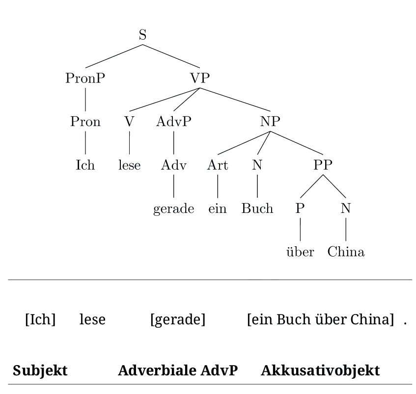

Beispiel

# Sprachvariation

**Übungsaufgabe 9** Eine Sprache (z.B. Deutsch oder Chinesisch) ist kein einheitliches Gebilde, sondern besteht aus vielen Varietäten. Sprachnutzer beherrschen in der Regel mehrere Varietäten ihrer Erstsprache. **Beschreiben Sie** Ihren eigenen chinesischen Sprachgebrauch in dieser Hinsicht. **Nutzen Sie** dabei geeignete sprachwissenschaftliche Fachbegriffe (z.B. Register, Dialekt, Soziolekt). **Veranschaulichen Sie** Ihre Beschreibung mit Beispielen. (100-200 Wörter, 12 Punkte)